# Session 5

18/11/2020

## Session 5: Comparing means

## Exercises for today

Defining the correct statistical test based on different case studies and implement this in R.

## Question 1

```r
# First update package
library(edcpR)
data(plant_growth, package = "edcpR")
```

We study the effect of a new fertilizer (NPK) on the growth of maize. We measured the yield in 10 control plots (Ctrl) vs 10 plots that received the fertilizer treatment.

**Research question**: What is the effect of fertilizer on the biomass yield of maize?

## Question 1 Solution (1)

```r
data(plant_growth, package = "edcpR")
colnames(plant_growth) <- c("Yield", "Treatment")
head(plant_growth)
```

```
##   Yield Treatment
## 1  4.17      ctrl
## 2  5.58      ctrl
## 3  5.18      ctrl
## 4  6.11      ctrl
## 5  4.50      ctrl
## 6  4.61      ctrl
```

## Question 1 Solution (2)

```r
str(plant_growth)
```

```
## 'data.frame':    20 obs. of  2 variables:
##  $ Yield    : num  4.17 5.58 5.18 6.11 4.5 4.61 5.17 4.53 5.33 5.14 ...
##  $ Treatment: Factor w/ 2 levels "ctrl","trt2": 1 1 1 1 1 1 1 1 1 1 ...
```

```r
plant_growth$Treatment <- as.factor(plant_growth$Treatment)
str(plant_growth)
```

```
## 'data.frame':    20 obs. of  2 variables:
##  $ Yield    : num  4.17 5.58 5.18 6.11 4.5 4.61 5.17 4.53 5.33 5.14 ...
##  $ Treatment: Factor w/ 2 levels "ctrl","trt2": 1 1 1 1 1 1 1 1 1 1 ...
```

## Question 1 Solution (3)

```r
# Difference in a quantitative variable between two groups
# Sample size = 20
# Too small for a parametric test --> non-parametric test preferred!
# Independent samples? --> check!
# Independent two-group Mann-Whitney test
wilcox.test(Yield ~ Treatment, data = plant_growth)
```

```
##
##  Wilcoxon rank sum exact test
##
## data:  Yield by Treatment
## W = 25, p-value = 0.06301
## alternative hypothesis: true location shift is not equal to 0
```

## Let’s consider sample size being large enough…

## Question 1 Solution (4)

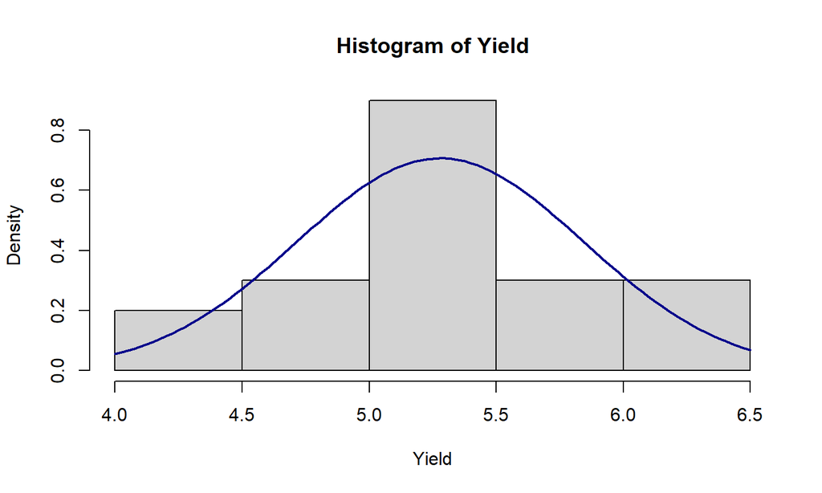

```r
# We can check if normality holds
hist(plant_growth$Yield, prob=TRUE, xlab="Yield",main="Histogram of Yield")
curve(dnorm(x, mean=m, sd=std),col="darkblue", lwd=2, add=TRUE, yaxt="n")
```

## Question 1 Solution (5)

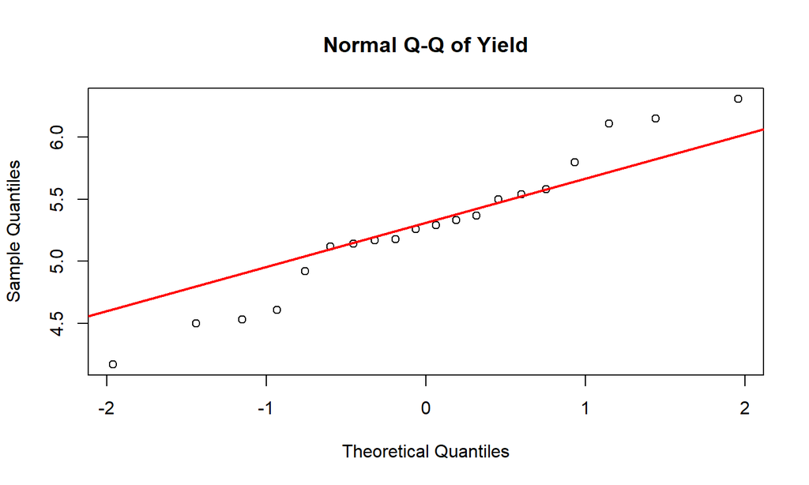

```r
qqnorm(plant_growth$Yield, main="Normal Q-Q of Yield")
qqline(plant_growth$Yield, col = "red", lwd = 2)
```